# Practical Machine Learning Project - Predict Movement Analysis Report

YeongWei

Tuesday, January 19, 2016

# Introduction

The classifications / outcomes are as below,

1. Class A - exactly according to the specification
2. Class B - throwing the elbows to the front
3. Class C - lifting the dumbbell only halfway
4. Class D - lowering the dumbbell only halfway
5. Class E - throwing the hips to the front

More information of the experiment can be found at http://groupware.les.inf.puc-rio.br/har.

# User Defined Function

The section consist the various user defined function definitions with descriptions that are used in the modeling section. The purpose is to make the source code in modeling concise.

### downloadFile

If file is not found in destination path then proceed to download.

```r
downloadFile <- function(url, file, destination="./") {
  if (!file.exists(paste(destination, file, sep=""))) {
      download.file(url=paste(url, file, sep=""),
                    dest=paste(destination, file, sep=""), method="curl")
  }
}
```

### loadOrInstallPackage

If package is not installed then proceed to installation then followed by loading into environment.

```r
loadOrInstallPackage <- function(packageName, ret=TRUE) {
  findPackage <- function(packageName)
    packageName %in% rownames(installed.packages())

  if (!findPackage(packageName)) install.packages(packageName)
  if (findPackage(packageName))
    suppressWarnings(suppressMessages(library(packageName, character.only=TRUE)))
  if (ret) found
}
```

### purgeNAColumns

If column has 80% or more of *NA* then drop column.

```r
purgeNAColumns <- function(dataFrame, purgableThreshold=0.8) {
  dataFrame[, ! colSums(is.na(dataFrame)) / nrow(dataFrame) >= purgableThreshold]
}
```

### obviousColumnReduction

Drop columns based on column names.

```r
obviousColumnReduction <- function(dataFrame, columns) {
  dataFrame[, ! (names(dataFrame) %in% columns)]
}
```

### rationalizeFactorColumns

If a column in *dataFrame1* is of type *factor* then make the same column in *dataFrame2* as *factor*.

```r
rationalizeFactorColumns <- function(dataFrame1, dataFrame2) {
  for (colName in names(dataFrame1)) {
    if (is.factor(dataFrame1[, colName])) {
      dataFrame2[, colName] <- as.factor(dataFrame2[, colName])
    }
  }
  dataFrame2
}
```

### readCsv

A wraper for *read.csv*.

```r
readCsv <- function(pathToFile, headerFlag=TRUE, naStrings=c("NA")) {
  read.csv(file=pathToFile, header=headerFlag, na.strings=naStrings)
}
```

# Library

This section attempts to load the required packages with `loadOrInstallPackage`.

```r
loadOrInstallPackage("caret", FALSE)
loadOrInstallPackage("rpart", FALSE)
loadOrInstallPackage("randomForest", FALSE)
loadOrInstallPackage("parallel", FALSE)
loadOrInstallPackage("doParallel", FALSE)
loadOrInstallPackage("corrplot", FALSE)
loadOrInstallPackage("rpart.plot", FALSE)
```

# Seed

This section attempts to set the `seed` value.

```r
set.seed(212121)
```

# Data Processing

This section attempts to retrieve and prepare the data.

```r
downloadUrl <- "https://d396qusza40orc.cloudfront.net/predmachlearn/"
trainingDataFile <- "pml-training.csv"
testingDataFile <- "pml-testing.csv"
```

## Downloading Data

This section attempts to download CSV files with `downloadFile`.

```r
downloadFile(downloadUrl, trainingDataFile)
downloadFile(downloadUrl, testingDataFile)
```

## Cleaning Data

This section attempts clean the downloaded data.

1. Assuming some values to be *NA* with the `readCsv` evaluation

```r
naStrings <- c("NA", "#DIV/0!", " ", "")
trainingDataFrame <- readCsv(trainingDataFile, TRUE, naStrings)
testingDataFrame <- readCsv(testingDataFile, TRUE, naStrings)
```

2. Dropping columns with values 80% are *NA* with `purgeNAColumns`

```r
trainingDataFrame <- purgeNAColumns(trainingDataFrame)
testingDataFrame <- purgeNAColumns(testingDataFrame)
```

3. Droping the unnecessary columns with `obviousColumnReduction`

```r
obviousReducibleColumns <- c("X", "user_name", "raw_timestamp_part_1",
                             "raw_timestamp_part_2", "cvtd_timestamp",
                             "new_window", "num_window")

trainingDataFrame <- obviousColumnReduction(trainingDataFrame,
                                             obviousReducibleColumns)
testingDataFrame <- obviousColumnReduction(testingDataFrame,
                                           obviousReducibleColumns)
```

# Modeling

This sections attempts to build 2 prediction models based on *Decision Tree* and *Random Forest* algorithm.

## Create Training and Testing Dataset

This section attemtps to construct the training(60%) and testing(40%) dataset from the cleaned data.

```r
inTrain <- createDataPartition(y=trainingDataFrame$classe, p=0.6, list=FALSE)
training <- trainingDataFrame[inTrain, ]
testing <- trainingDataFrame[-inTrain, ]
```

## Create Control Parameter for Model Training

The control parameter below attempts to exploit the parallel processing feature by creating processing cluster based on the number of CPU cores available.

```r
cluster <- makeCluster(detectCores() -1) # convention to leave 1 core for OS
registerDoParallel(cluster)
fitControl <- trainControl(method="cv", number=5, allowParallel=TRUE)
```

## Prediction Model with Decision Tree

Training the model with the *rpart* method.

```r
modelFitDecisionTree <- train(classe ~ ., method="rpart", data=training, trControl=fitControl)
predictionDecisionTree <- predict(modelFitDecisionTree, testing)
cmDecisionTree <- confusionMatrix(testing$classe, predictionDecisionTree)
cmDecisionTree
```

```
## Confusion Matrix and Statistics
##
##           Reference
## Prediction    A    B    C    D    E
##          A 2010   40  177    0    5
##          B  624  534  360    0    0
##          C  629   33  706    0    0
##          D  540  240  506    0    0
##          E  192  186  403    0  661
##
## Overall Statistics
##
##                Accuracy : 0.4985
##                  95% CI : (0.4873, 0.5096)
##     No Information Rate : 0.5092
##     P-Value [Acc > NIR] : 0.9718
##
##                   Kappa : 0.3455
##  Mcnemar's Test P-Value : NA
##
## Statistics by Class:
##
##                      Class: A Class: B Class: C Class: D Class: E
## Sensitivity            0.5031  0.51694  0.32807       NA  0.99249
## Specificity            0.9424  0.85557  0.88374   0.8361  0.89123
## Pos Pred Value         0.9005  0.35178  0.51608       NA  0.45839
## Neg Pred Value         0.6464  0.92114  0.77678       NA  0.99922
## Prevalence             0.5092  0.13166  0.27428   0.0000  0.08488
## Detection Rate         0.2562  0.06806  0.08998   0.0000  0.08425
## Detection Prevalence   0.2845  0.19347  0.17436   0.1639  0.18379
## Balanced Accuracy      0.7227  0.68626  0.60590       NA  0.94186
```

## Prediction Model with Random Forest

Training the model with *rf* method.

```r
modelFitRandomForest <- train(classe ~ ., method="rf", data=training, trControl=fitControl)
predictionRandomForest <- predict(modelFitRandomForest, testing)
cmRandomForest <- confusionMatrix(testing$classe, predictionRandomForest)
cmRandomForest
```

```
## Confusion Matrix and Statistics
##
##           Reference
## Prediction    A    B    C    D    E
##          A 2228    3    1    0    0
##          B   14 1503    1    0    0
##          C    0    2 1359    7    0
##          D    0    0    7 1279    0
##          E    2    0    4    5 1431
##
## Overall Statistics
##
##                Accuracy : 0.9941
##                  95% CI : (0.9922, 0.9957)
##     No Information Rate : 0.286
##     P-Value [Acc > NIR] : < 2.2e-16
##
##                   Kappa : 0.9926
##  Mcnemar's Test P-Value : NA
##
## Statistics by Class:
##
##                      Class: A Class: B Class: C Class: D Class: E
## Sensitivity            0.9929   0.9967   0.9905   0.9907   1.0000
## Specificity            0.9993   0.9976   0.9986   0.9989   0.9983
## Pos Pred Value         0.9982   0.9901   0.9934   0.9946   0.9924
## Neg Pred Value         0.9971   0.9992   0.9980   0.9982   1.0000
## Prevalence             0.2860   0.1922   0.1749   0.1645   0.1824
## Detection Rate         0.2840   0.1916   0.1732   0.1630   0.1824
## Detection Prevalence   0.2845   0.1935   0.1744   0.1639   0.1838
## Balanced Accuracy      0.9961   0.9972   0.9946   0.9948   0.9991
```

## Analysis between Prediction Models

This section evaluates the overall accuracy and estimate the out-of-sample error.

Helper function below computes the estimated out-of-sample error,

```r
computeFunc <- function (value) {
  1 - as.numeric(value)
}
```

Helper function returns the argument,

```r
retFunc <- function(arg) {
  arg
}
```

Helper function below returns the percentagized string,

```r
percentagize <- function(value, func) {
  paste(round(func(value) * 100, 2), "%")
}
```

### Decision Tree

1. The overall accuracy is,

```r
percentagize(cmDecisionTree$overall[1], retFunc)
```

```
## [1] "49.85 %"
```

2. The estimated out-of-sample error is,

```r
percentagize(cmDecisionTree$overall[1], computeFunc)
```

```
## [1] "50.15 %"
```

### Random Forest

1. The overall accuracy is,

```r
percentagize(cmRandomForest$overall[1], retFunc)
```

```
## [1] "99.41 %"
```

2. The estimated out-of-sample error is,

```r
percentagize(cmRandomForest$overall[1], computeFunc)
```

```
## [1] "0.59 %"
```

# Conclusion / Result

Based on the Modeling section, the prediction model with Random Forest is better than the Decision Tree algorithm.

Therefore the Random Forest prediction model is used to predict the outcome (classe column) for the `testingDataFrame` test data from the Cleaning Data section.

```r
prediction <- predict(modelFitRandomForest, testingDataFrame)
```

The predicted outcomes are arranged as follows,

```r
predictionDf <- data.frame(index=c(1: length(prediction)), prediction=prediction)
predictionDf
```

```
##    index prediction
## 1      1          B
## 2      2          A
## 3      3          B
## 4      4          A
## 5      5          A
## 6      6          E
## 7      7          D
## 8      8          B
## 9      9          A
## 10    10          A
## 11    11          B
## 12    12          C
## 13    13          B
## 14    14          A
## 15    15          E
## 16    16          E
## 17    17          A
## 18    18          B
## 19    19          B
## 20    20          B
```

# Appendix

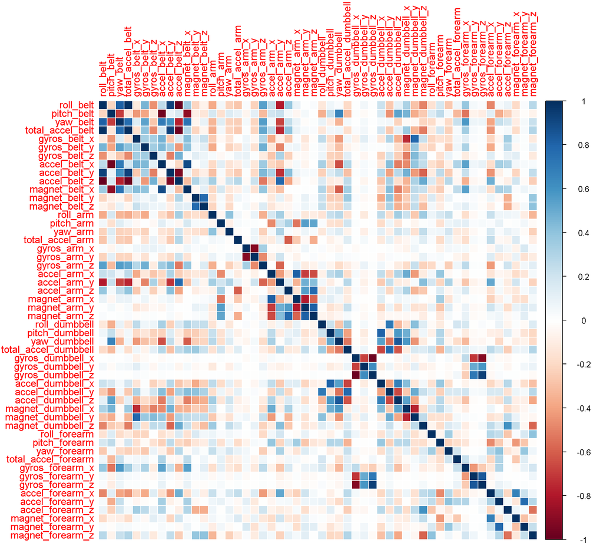

```r
corrPlot <- cor(trainingDataFrame[, -length(names(trainingDataFrame))])
corrplot(corrPlot, method="color")
```

2. Decision Tree visualization forDecision Tree prediction model.

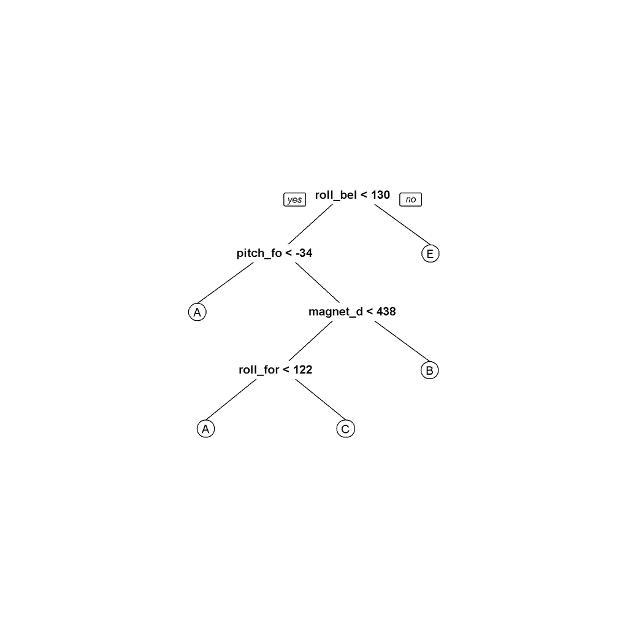

```r
prp(modelFitDecisionTree$finalModel)
```